# Identify Sepsis

Fei Ding

September 18, 2019

# Suspected Infection

Suspected infection was defined as combination of antibiotics and body fluid cultures:

- If the antibiotic was given first, the culture sampling must have been obtained within 1 day.
- If the culture sampling was first, the antibiotic must have been ordered dwithin 3 days.
- The onset date of infection was the date on which the first of these two events occured.
- We added an addtional requirement that the onset date must be $\pm1$ day within hospital admission date.

*Note that we only have blood culture dates now, the definition is any body fluid cultures (blood, unrine, cerebrospinal fluid, etc)*

Out of 114,897 ICU encounters with CAM-ICU assessments, 24,827 (21.6%) had suspected infections within $\pm1$ day of hospital admission date.

Distribution of onset day

| onset_day | n |
| --- | --- |
| 0 | 2256 |
| 1 | 19317 |
| 2 | 3254 |

# SOFA score

We have data or partial data for

- Coagulation SOFA score (platelets)
- Liver SOFA score (bilirubin)
- Central nervous system SOFA score (RASS score)
- cardiovascular SOFA score (pressors)

SOFA score was calculated from the time window from 2 days before to 1 day after the onset of infection. Total SOFA score was calculated using available SOFA scores for any of the four systems. Thus, our SOFA score is an underestimate of the actual SOFA score.

Central nervous system SOFA score calculated based on RASS Method C in the Modified SOFA score paper.

| Rass score | SOFA score |
| --- | --- |
| $\ge$ 0 | 0 |
| -1 | 1 |
| -2 | 2 |
| -3 | 3 |
| -4 to -5 | 4 |

Cardiovascular SOFA score calculated based on pressor use.

| Pressor Use | SOFA score |
| --- | --- |
| Any epinepherine or norepinephrine | 3 |
| Any dopamine or dobutamine | 2 |

*Note the SOFA table requires the catecholamine doses are given for at least 1 hour*

## Non-numerical Lab values

Out of range values for bilirubin were converted as following.

Out of range bilirubin

| oor_value | Tbil (mg/dL) |
| --- | --- |
| <0.1 | 0.1 |
| 0.4<br>Result | 0.4 |
| <0.5 | 0.5 |
| >25.0 | 25.0 |
| <0.2 | 0.2 |
| <0.10 | 0.1 |
| 0.0-1.0 | 0.5 |
| <0.4 | 0.4 |
| <0.3 | 0.3 |
| <1.1 | 1.1 |
| <1.7 | 1.7 |
| 31.3<br>Result | 31.3 |
| > | NA |
| <.2 | 0.2 |

Out of range values for platelets were converted as following.

Out of range platelets

| oor_value | Plt-Ct (thou/uL) |
| --- | --- |
| <5 | 5 |
| 150-400 | 275 |
| <br>64 | 64 |
| 500K | 500 |
| 112Credited | 112 |
| <10 | 10 |

## Distribution of SOFA score

```
##    Min. 1st Qu.  Median    Mean 3rd Qu.    Max.    NA's
##   0.000   1.000   3.000   3.366   5.000  15.000       8
```

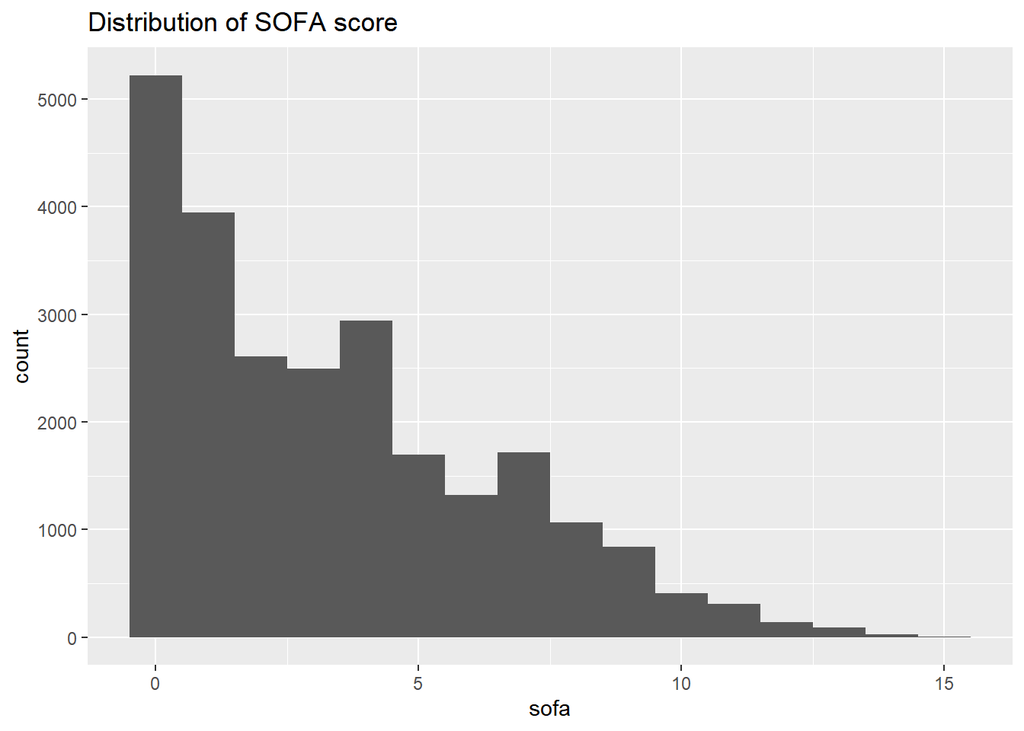

## Missing Data

Cardio and Liver system had the most missing data.

Percent of missing data for each system

|  | % missing |
| --- | --- |
| sofa_coagulation | 0.898% |
| sofa_liver | 21.9% |
| sofa_cardio | 74.0% |
| sofa_cns | 2.53% |

Data composition of all suspected infections

| data_type | n | pct |
| --- | --- | --- |
| All missing | 8 | 0.03% |
| Complete data | 5521 | 22.24% |
| Missing > 1 system | 5033 | 20.27% |
| No Cardio SOFA | 13388 | 53.93% |
| No CNS SOFA | 20 | 0.08% |
| No Coagulation SOFA | 2 | 0.01% |
| No Liver SOFA | 855 | 3.44% |

Although there is a lot missing, Out of the 24,827 suspected infections,13,039 (52.5%) of SOFA scores are already > 2 calculated using available data, that is 11.3% of ICU encounters had sepsis.

Data composition for SOFA < 2

| data_type | n | pct |
| --- | --- | --- |
| Missing > 1 system | 3405 | 37.1% |
| No Cardio SOFA | 5767 | 62.9% |

## What I need

- I will need DOB of all updated_GRIDs in changed_GRIDs file to correctly convert dates in lab data.
- When do we do SOFA score change, when do we use absolute value?